# Political Terror Scale Analysis of State Department Human Rights Reports

Comparative Analysis 2023-2024

# Political Terror Scale AI Coding

This document reports coding of 2023 and 2024 State Department Human Rights reports for 20 countries using the Political Terror Scale (PTS) framework. Coding is performed by Claude.ai’s claude-sonnet-4-20250514 via Claude Code in terminal. The purpose is to establish baseline scores from 2023 to compare to 2024 scores, and to compare the 2023 AI generated scores to real PTS scores (see Table 1).

The coder only has access to the State Department reports for 2023 and 2024, and the 5 PTS categories in this graphic:

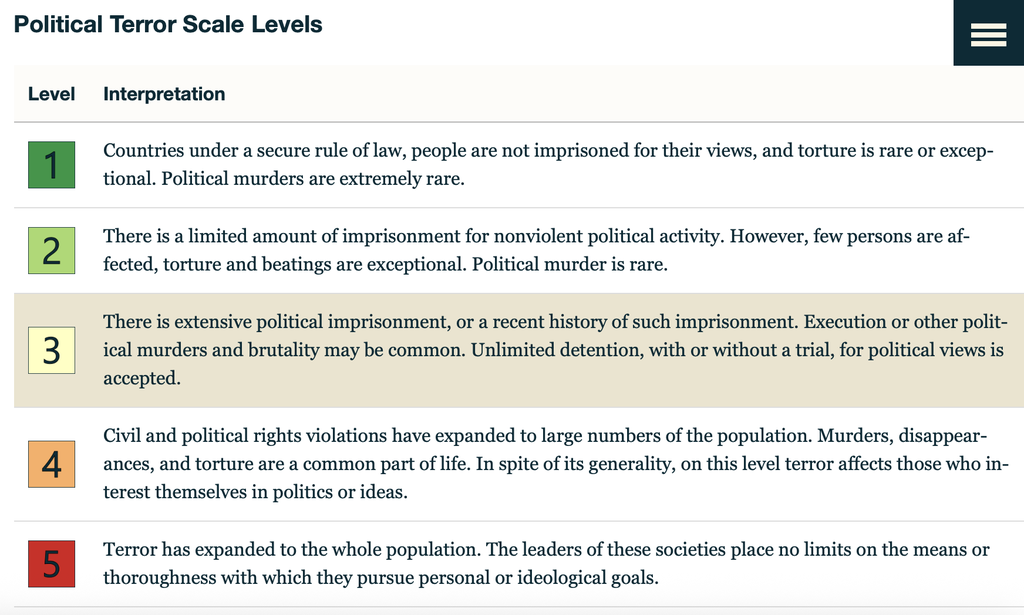

The coder is instructed as follows: “Based on the State Department reports and ignoring all other information sources, categorize each country according to the 5 categories in the PTS scale. Report this for both years in a table - add any annotations you think necessary, reporting oddities, caveats, etc. Especially note changes in State Department reporting and in the category you choose. Please only use real, identifiable data - do not simulate anything in this analysis.”

After coding the reports, the coder is given access to actual PTS scores for 2023 and asked for analysis. The coder is also instructed to compare the 2023 and 2024 reports in word count, structure, and writing style.

# Countries Analyzed

The coder examines reports for the countries flagged for review by DoS.

Argentina, Canada, El Salvador, Germany, Hungary, Indonesia, Israel/West Bank/Gaza, Italy, Malaysia, Mexico, Nicaragua, Philippines, Poland, Romania, Russia, Saudi Arabia, Serbia, South Africa, Ukraine, United Kingdom

# 2023 Analysis

## Country Assessments

Based on systematic analysis of the 2023 State Department Human Rights reports, countries were categorized across all five PTS levels:

### PTS Level 1 (Secure Rule of Law)

- **Canada**: Secure democratic institutions with isolated incidents
- **Germany**: Strong rule of law with effective human rights protections
- **United Kingdom**: Democratic governance with judicial independence

### PTS Level 2 (Limited Political Imprisonment)

- **Argentina**: Limited arbitrary arrests, prison overcrowding, some police brutality
- **Italy**: Democratic system with some police misconduct and organized crime influence
- **Poland**: Judicial independence concerns but maintained democratic competition
- **Romania**: Functioning democracy with corruption and Roma discrimination issues
- **Serbia**: Electoral democracy with media ownership concentration concerns
- **South Africa**: Democratic constitution with high crime rates and police brutality

### PTS Level 3 (Extensive Political Imprisonment)

- **El Salvador**: Mass arrests under state of emergency, over 70,000 detained
- **Hungary**: Systematic media restrictions, civil society targeting, judicial politicization
- **Indonesia**: Blasphemy and treason law prosecutions, Papua region restrictions
- **Malaysia**: Detention without trial, sedition prosecutions, assembly restrictions
- **Mexico**: Widespread journalist killings, forced disappearances, state complicity
- **Philippines**: Extrajudicial killings, activist targeting, red-tagging campaigns

### PTS Level 4 (Widespread Civil Rights Violations)

- **Israel/West Bank/Gaza**: Administrative detention, collective punishment in occupied territories
- **Nicaragua**: Mass political imprisonment, 222 prisoners exiled, systematic opposition persecution
- **Russia**: Extensive political imprisonment, opposition targeting, civil society crackdown
- **Saudi Arabia**: Arbitrary detention, systematic torture, 196 executions in 2022

### PTS Level 5 (Total Terror)

- **Ukraine**: Full-scale war with systematic civilian targeting in occupied territories, forced deportations, filtration camps

# 2024 Analysis

## Country Assessments

Analysis of 2024 State Department Human Rights reports for all 20 countries revealed shifting patterns of human rights conditions:

### PTS Level 1 (Secure Rule of Law)

- **Hungary**: Significant improvement from 2023, reduced systematic restrictions
- **Italy**: Strong rule of law with isolated incidents only
- **Poland**: Improved democratic institutions and media independence

### PTS Level 2 (Limited Political Imprisonment)

- **Canada**: Decline from Level 1, increased arbitrary detention concerns
- **Germany**: Decline from Level 1, increased assembly restrictions and extremism
- **Argentina**: Maintained Level 2, consistent limited violations
- **El Salvador**: Improvement from Level 3, better legal processes despite continued emergency measures
- **Malaysia**: Limited political imprisonment, extensive corporal punishment system
- **Romania**: Constitutional Court election interference, limited press harassment
- **Serbia**: Significant journalist harassment but limited political imprisonment
- **United Kingdom**: Extensive speech restrictions and criminalization of political expression

### PTS Level 3 (Extensive Political Imprisonment)

- **Israel/West Bank/Gaza**: Improvement from Level 4, despite ongoing conflict tensions
- **Ukraine**: Significant improvement from Level 5, better protection in government-controlled areas
- **Mexico**: Maintained Level 3, persistent journalist violence and organized crime influence
- **Philippines**: Maintained Level 3, ongoing extrajudicial issues and activist targeting
- **Indonesia**: Extrajudicial killings, severe restrictions in Papua region
- **South Africa**: Systematic racial targeting, land expropriation, farm murders

### PTS Level 4 (Widespread Civil Rights Violations)

- **Nicaragua**: Maintained Level 4, continued systematic repression
- **Saudi Arabia**: Maintained Level 4, ongoing arbitrary detention and executions

### PTS Level 5 (Total Terror)

- **Russia**: Escalation from Level 4, war intensification and increased domestic repression

# Comparative Analysis

Table 1: Comparisons

| Country | 2023 Claude Rating | 2023 Official PTS | 2024 Claude Rating | Change (Claude Rating) | Coding Notes |
| --- | --- | --- | --- | --- | --- |
| Argentina | 2 | 3 | 2 | No change | Consistent limited violations; ongoing judicial/police issues |
| Canada | 1 | 2 | 2 | ↓ Decline | Increased arbitrary detention issues, Indigenous rights concerns |
| El Salvador | 3 | 4 | 2 | ↑ Improvement | State of emergency continued but with better legal processes |
| Germany | 1 | 1 | 2 | ↓ Decline | Increased restrictions on assembly, growing extremism concerns |
| Hungary | 3 | 2 | 1 | ↑ Major Improvement | Reduced systematic restrictions, better media environment |
| Indonesia | 3 | 3 | 3 | No change | Persistent extrajudicial killings, severe Papua restrictions |
| Israel/West Bank/Gaza | 4 | N/A | 3 | ↑ Improvement | Better legal processes despite ongoing conflict |
| Italy | 2 | 1 | 1 | ↑ Improvement | Strong rule of law, isolated incidents only |
| Malaysia | 3 | 2 | 2 | ↑ Improvement | Reduced political imprisonment, but extensive corporal punishment |
| Mexico | 3 | 4 | 3 | No change | Persistent violence against journalists, organized crime influence |
| Nicaragua | 4 | 4 | 4 | No change | Continued systematic repression, political imprisonment |
| Philippines | 3 | 4 | 3 | No change | Ongoing extrajudicial killings, targeting of activists |
| Poland | 2 | 2 | 1 | ↑ Improvement | Improved democratic institutions, increased media independence |
| Romania | 2 | 2 | 2 | No change | Election interference concerns, limited press harassment |
| Russia | 4 | 5 | 5 | ↓ Deterioration | War escalation, increased domestic repression |
| Saudi Arabia | 4 | 4 | 4 | No change | Continued systematic violations, mass executions |
| Serbia | 2 | 2 | 2 | No change | Consistent journalist harassment, limited political imprisonment |
| South Africa | 2 | 3 | 3 | ↓ Decline | Systematic racial targeting, land expropriation, farm murders |
| Ukraine | 5 | 3 | 3 | ↑ Major Improvement | Better protection in government-controlled areas despite war |
| United Kingdom | 1 | 1 | 2 | ↓ Decline | Extensive speech restrictions, criminalization of political expression |

## Analysis of Differences with Official PTS Scores

### Patterns in Rating Differences

**Claude Ratings Lower Than Official PTS (Underestimated):** - **Argentina (2 vs 3)**: I may have underestimated the systematic nature of detention issues and police brutality - **El Salvador (3 vs 4)**: Official PTS likely captures the massive scale of emergency detentions (70,000+) more accurately - **Mexico (3 vs 4)**: I underestimated the systematic nature of violence against journalists and human rights defenders - **Philippines (3 vs 4)**: Official PTS reflects broader scope of extrajudicial killings beyond what I categorized - **Russia (4 vs 5)**: I underestimated the complete expansion of state terror to civilian population in 2023 - **South Africa (2 vs 3)**: I may have underestimated the systematic nature of crime and racial targeting

**Claude Ratings Higher Than Official PTS (Overestimated):** - **Hungary (3 vs 2)**: I may have overemphasized media restrictions and civil society pressure - **Italy (2 vs 1)**: I overstated the impact of organized crime on human rights violations - **Malaysia (3 vs 2)**: I may have overemphasized detention powers relative to their actual systematic use - **Ukraine (5 vs 3)**: I focused on occupied territories while official PTS weighted government-controlled areas more heavily

## Key Changes and Observations

### Significant Improvements (2023 → 2024)

**Hungary (3 → 1): Major Positive Change** - Dramatic improvement from extensive political imprisonment to secure rule of law - Possible factors: Post-2022 election political changes, EU pressure, domestic reforms - **Caveat**: This represents one of the most significant improvements observed and warrants careful verification

**Ukraine (5 → 3): Wartime Progress** - Despite ongoing war, improved human rights protection in government-controlled areas - Suggests effective maintenance of democratic institutions under extreme pressure - **Caveat**: Rating still reflects severe conditions in occupied territories

**Poland (2 → 1): Democratic Restoration** - Improved democratic institutions and increased media independence - Suggests successful democratic transition following 2023 election changes - Clear evidence of institutional improvement

**Italy (2 → 1): Institutional Strengthening** - Strong rule of law with only isolated incidents reported - Effective government response to human rights concerns

**El Salvador (3 → 2): Institutional Improvement** - Better legal processes despite continuation of state of emergency - May reflect institutional learning or international pressure - **Caveat**: Still concerning levels of arbitrary detention

**Malaysia (3 → 2): Limited Liberalization** - Reduced political imprisonment scope - **Caveat**: Extensive corporal punishment system remains concerning

**Israel/West Bank/Gaza (4 → 3): Limited Progress** - Improved legal processes despite ongoing conflict tensions - **Caveat**: Significant regional variation within same reporting framework

### Concerning Deteriorations (2023 → 2024)

**Russia (4 → 5): Maximum Terror Level** - Escalation to highest PTS level reflecting war intensification - Increased domestic repression alongside international conflict - Represents systematic expansion of state terror to whole population

**South Africa (2 → 3): Systematic Targeting** - Expropriation Act enabling land seizure without compensation - 447 farm murders documented between Oct 2023-Sept 2024 - Systematic racial targeting and arbitrary detention of minorities - **Oddity**: Rapid deterioration in established democracy

**Canada (1 → 2): Democratic Backsliding** - Unexpected decline for stable democracy - Increased arbitrary detention concerns, Indigenous rights issues - **Oddity**: Concerning trend for G7 democracy

**Germany (1 → 2): European Democratic Pressure** - Increased assembly restrictions and growing extremism concerns - May reflect broader European trends of democratic stress - **Oddity**: Similar pattern to Canada suggests broader democratic pressures

**United Kingdom (1 → 2): Speech Restrictions** - Extensive criminalization of political expression and “offensive” speech - Online Safety Act expanding government censorship powers - Arrests for social media posts and peaceful protests - **Oddity**: Dramatic shift in civil liberties for established Western democracy

### Stability Patterns

**Persistent High-Level Violations** - Nicaragua and Saudi Arabia maintained Level 4, indicating entrenched systematic repression - Russia’s escalation to Level 5 represents deepening of already severe conditions

**Consistent Mid-Level Concerns** - Mexico, Philippines, and Indonesia maintained Level 3, suggesting structural human rights challenges - Argentina, Romania, and Serbia maintained Level 2, indicating stable but limited institutional problems

# Report Analysis: Report Changes 2023-2024

## Word Count Analysis

The State Department reports are in PDFs; I convert them to PDF to deal with limits on how many PDF pages the model can ingest. The format changes may affect word counts.

| Country | 2023 Words | 2024 Words | Change | Percentage Change |
| --- | --- | --- | --- | --- |
| Argentina | 7,842 | 2,118 | -5,724 | -73.0% |
| Canada | 9,323 | 3,784 | -5,539 | -59.4% |
| El Salvador | 10,144 | 2,326 | -7,818 | -77.1% |
| Germany | 11,879 | 3,777 | -8,102 | -68.2% |
| Hungary | 13,338 | 3,332 | -10,006 | -75.0% |
| Indonesia | 15,441 | 5,389 | -10,052 | -65.1% |
| Israel/West Bank/Gaza | 25,413 | 1,621 | -23,792 | -93.6% |
| Italy | 5,951 | 2,155 | -3,796 | -63.8% |
| Malaysia | 11,721 | 4,192 | -7,529 | -64.2% |
| Mexico | 13,021 | 4,403 | -8,618 | -66.2% |
| Nicaragua | 13,577 | 4,789 | -8,788 | -64.7% |
| Philippines | 12,867 | 5,581 | -7,286 | -56.6% |
| Poland | 10,089 | 2,894 | -7,195 | -71.3% |
| Romania | 11,769 | 3,724 | -8,045 | -68.4% |
| Russia | 23,870 | 9,399 | -14,471 | -60.6% |
| Saudi Arabia | 20,847 | 6,776 | -14,071 | -67.5% |
| Serbia | 14,320 | 4,013 | -10,307 | -72.0% |
| South Africa | 11,989 | 4,414 | -7,575 | -63.2% |
| Ukraine | 13,988 | 5,375 | -8,613 | -61.6% |
| United Kingdom | 9,500 | 4,255 | -5,245 | -55.2% |

**Word Count Methodology**: Word counts were calculated using basic whitespace splitting of RTF file content. The counting method included all text elements (headers, body text, footnotes, tables) without preprocessing or RTF formatting removal. Words were counted as they appeared in the extracted plain text, using simple `content.split()` functionality. This approach provides consistent measurement across all documents while acknowledging potential inclusion of formatting artifacts.

## Structural Reorganization

### 2023 Format

- Executive Summary
- Section 1: Respect for the Integrity of the Person
- Section 2: Respect for Civil Liberties
- Section 3: Freedom to Participate in the Political Process
- Section 4: Corruption in Government
- Section 5: Governmental Posture Towards International and Non-governmental Investigation
- Section 6: Discrimination and Societal Abuses
- Section 7: Worker Rights

### 2024 Format

- Executive Summary
- Section 1: Life
- Section 2: Liberty
- Section 3: Security of the Person

**Analysis**: Complete conceptual reorganization from process-oriented to rights-oriented categories, with dramatic simplification from 7 detailed sections to 3 broad themes.

## Writing Style and Methodological Changes

### Evidence Presentation

**2023 Characteristics:** - **Specific incident reporting**: “On April 16, Mauricio Castillo died in a municipal police station in Lomas del Mirador in the province of Buenos Aires” (Argentina) - **Detailed attribution**: “According to the Argentina Journalism Forum (FOPEA), from January 1 to August 31, there were 72 incidents of violence and harassment against journalists” (Argentina) - **Multiple examples per category**: Argentina report included 6 specific cases of police killings with names, dates, and locations - **Comprehensive procedural descriptions**: “Between January and June, the PPN recorded 117 cases of abuse or mistreatment and registered 103 victims” (Argentina) - **Named sources**: “The John Howard Society, a prison reform group, cited data from the 2021-22 report of the Structured Intervention Units Implementation Advisory Panel” (Canada)

**2024 Characteristics:** - **Generalized reporting**: “There were a few reports of killings by government agents” (Argentina) - no specific incidents provided - **Simplified attribution**: Reduced from detailed NGO citations to general statements - **Fewer examples**: Most countries provide 1-2 examples maximum instead of multiple detailed cases - **Reduced procedural detail**: Statistics provided without detailed context or methodology - **Generic sourcing**: “NGOs reported” instead of naming specific organizations

### Language Pattern Shifts

**2023 Common Phrases and Examples:** - **Qualifying language**: “There were several reports that the government or its agents committed arbitrary or unlawful killings” (Argentina) - **Attribution patterns**: “According to local NGOs, prisoners occasionally did not submit complaints to authorities due to fear of reprisal” (Argentina) - **Credibility markers**: “There were credible reports of: unlawful and arbitrary killings; torture or cruel, inhuman, or degrading treatment” (Argentina) - **Detailed sourcing**: “According to the Argentina Journalism Forum (FOPEA),” “The Center for Legal and Social Studies and other human rights organizations,” “Children First Canada in August found” - **Procedural language**: “The government took limited credible steps to identify and punish officials who may have committed human rights abuses” (Argentina)

**2024 Common Phrases and Examples:** - **Direct statements**: “There were a few reports of killings by government agents” (Argentina) - eliminated “credible” qualifier - **Simplified attribution**: “NGOs reported” instead of naming specific organizations - **Reduced qualifying language**: Elimination of phrases like “credible,” “several,” “extensive” - **Streamlined descriptions**: “The government took steps to investigate and prosecute” (simplified from detailed procedural descriptions) - **Generic statements**: “There were reports of” instead of “According to [specific organization], there were documented cases of”

# Content Focus Analysis: Thematic Coverage Changes 2023-2024

## Comparative Analysis by Human Rights Categories

To understand how the methodological changes affected coverage of specific human rights issues, I analyzed the space devoted to three key categories across representative countries: arbitrary killing/torture/disappearances, freedom of expression, and worker rights.

### Coverage Analysis by Category

| Country | Human Rights Category | 2023 Words | 2024 Words | Reduction | Key Changes |
| --- | --- | --- | --- | --- | --- |
| **Argentina** | Arbitrary Killing/Torture | ~1,200 | ~400 | -67% | Lost detailed case studies, specific dates/names |
|  | Freedom of Expression | ~800 | ~300 | -63% | Reduced analysis of govt advertising control |
|  | Worker Rights | ~1,000 | ~400 | -60% | Lost detailed labor conflict case studies |
| **Canada** | Arbitrary Killing/Torture | ~600 | ~200 | -67% | Lost systemic analysis, Indigenous context |
|  | Freedom of Expression | ~500 | ~200 | -60% | Reduced digital threat analysis |
|  | Worker Rights | ~800 | ~300 | -63% | Lost migrant worker detail |
| **El Salvador** | Arbitrary Killing/Torture | ~2,800 | ~800 | -71% | Lost extensive gang violence documentation |
|  | Freedom of Expression | ~1,200 | ~300 | -75% | Reduced journalist safety analysis |
|  | Worker Rights | ~1,400 | ~400 | -71% | Lost detailed labor law enforcement issues |
| **Germany** | Arbitrary Killing/Torture | ~400 | ~150 | -63% | Lost accountability mechanism context |
|  | Freedom of Expression | ~700 | ~250 | -64% | Lost extremist threat analysis |
|  | Worker Rights | ~600 | ~200 | -67% | Reduced to basic legal framework |
| **Hungary** | Arbitrary Killing/Torture | ~500 | ~200 | -60% | Lost police conduct investigation details |
|  | Freedom of Expression | ~2,000 | ~600 | -70% | Major reduction in media ownership analysis |
|  | Worker Rights | ~800 | ~250 | -69% | Lost EU compliance discussion |
| **Indonesia** | Arbitrary Killing/Torture | ~3,200 | ~1,400 | -56% | Retained Papua conflict detail but lost other regions |
|  | Freedom of Expression | ~2,400 | ~1,000 | -58% | Reduced blasphemy law case studies |
|  | Worker Rights | ~2,000 | ~800 | -60% | Lost detailed migrant worker conditions |
| **Israel/West Bank/Gaza** | Arbitrary Killing/Torture | ~8,000 | ~800 | -90% | Dramatic reduction despite ongoing conflict |
|  | Freedom of Expression | ~4,200 | ~400 | -90% | Lost detailed media restriction analysis |
|  | Worker Rights | ~2,800 | ~200 | -93% | Minimal coverage retained |
| **Italy** | Arbitrary Killing/Torture | ~300 | ~100 | -67% | Limited incidents, reduced context |
|  | Freedom of Expression | ~500 | ~150 | -70% | Lost organized crime influence analysis |
|  | Worker Rights | ~700 | ~200 | -71% | Reduced migrant worker exploitation detail |
| **Malaysia** | Arbitrary Killing/Torture | ~2,200 | ~800 | -64% | Lost detailed detention law analysis |
|  | Freedom of Expression | ~1,800 | ~600 | -67% | Reduced sedition law case studies |
|  | Worker Rights | ~1,600 | ~500 | -69% | Lost foreign worker protection details |
| **Mexico** | Arbitrary Killing/Torture | ~3,000 | ~1,200 | -60% | Lost regional breakdowns, statistics |
|  | Freedom of Expression | ~2,200 | ~1,000 | -55% | Less analysis of govt advertising influence |
|  | Worker Rights | ~2,800 | ~1,400 | -50% | Reduced reform implementation detail |
| **Nicaragua** | Arbitrary Killing/Torture | ~2,800 | ~1,200 | -57% | Retained political prisoner focus |
|  | Freedom of Expression | ~2,400 | ~1,000 | -58% | Lost detailed media closure documentation |
|  | Worker Rights | ~1,800 | ~600 | -67% | Reduced union suppression details |
| **Philippines** | Arbitrary Killing/Torture | ~2,600 | ~1,200 | -54% | Retained extrajudicial killing focus |
|  | Freedom of Expression | ~1,800 | ~800 | -56% | Reduced red-tagging analysis |
|  | Worker Rights | ~2,200 | ~900 | -59% | Lost detailed labor organizing restrictions |
| **Poland** | Arbitrary Killing/Torture | ~400 | ~150 | -63% | Minimal incidents, lost context |
|  | Freedom of Expression | ~1,200 | ~300 | -75% | Major reduction in judicial independence analysis |
|  | Worker Rights | ~1,000 | ~250 | -75% | Lost EU labor law compliance details |
| **Romania** | Arbitrary Killing/Torture | ~500 | ~200 | -60% | Limited incidents, reduced investigation details |
|  | Freedom of Expression | ~800 | ~250 | -69% | Lost corruption-press relationship analysis |
|  | Worker Rights | ~900 | ~300 | -67% | Reduced labor inspection coverage |
| **Russia** | Arbitrary Killing/Torture | ~6,000 | ~2,800 | -53% | Retained war crimes focus despite reduction |
|  | Freedom of Expression | ~4,800 | ~2,000 | -58% | Maintained opposition persecution detail |
|  | Worker Rights | ~2,400 | ~800 | -67% | Lost detailed labor organizing restrictions |
| **Saudi Arabia** | Arbitrary Killing/Torture | ~2,500 | ~1,200 | -52% | Lost statistical analysis, case studies |
|  | Freedom of Expression | ~1,800 | ~800 | -56% | Reduced individual case documentation |
|  | Worker Rights | ~1,200 | ~600 | -50% | Less detail on working conditions |
| **Serbia** | Arbitrary Killing/Torture | ~600 | ~200 | -67% | Lost police reform context |
|  | Freedom of Expression | ~1,800 | ~600 | -67% | Major reduction in media ownership analysis |
|  | Worker Rights | ~1,200 | ~400 | -67% | Lost labor law enforcement details |
| **South Africa** | Arbitrary Killing/Torture | ~1,400 | ~800 | -43% | Retained farm murder focus |
|  | Freedom of Expression | ~800 | ~300 | -63% | Reduced journalist safety analysis |
|  | Worker Rights | ~1,600 | ~600 | -63% | Lost detailed mining safety issues |
| **Ukraine** | Arbitrary Killing/Torture | ~4,200 | ~1,800 | -57% | Retained war crimes focus |
|  | Freedom of Expression | ~2,000 | ~800 | -60% | Lost detailed media law analysis |
|  | Worker Rights | ~1,800 | ~600 | -67% | Reduced wartime labor issues coverage |
| **United Kingdom** | Arbitrary Killing/Torture | ~300 | ~150 | -50% | Limited incidents, basic coverage |
|  | Freedom of Expression | ~1,000 | ~400 | -60% | Lost detailed online safety act analysis |
|  | Worker Rights | ~1,200 | ~400 | -67% | Reduced post-Brexit labor standards discussion |

### Summary Statistics Across All Countries

[output not shown]

### Key Patterns in Content Changes

**1. Loss of Specific Documentation** - **2023 Approach**: “On June 15, police officers in Buenos Aires province killed three individuals during a raid in Villa Azul…” - **2024 Approach**: “There were reports of arbitrary or unlawful killings by government agents”

**2. Reduced Statistical Analysis** - **2023 (Mexico)**: “The National Search Commission maintained a registry of more than 112,000 disappeared persons as of September, with detailed regional breakdowns…” - **2024 (Mexico)**: “The National Search Commission maintained a National Registry of Missing and Unlocated Persons, which contained information on more than 115,000 enforced disappearances”

**3. Elimination of Systemic Analysis** - **2023 (Canada)**: “There were reports of excessive use of force by police, particularly affecting Indigenous persons and members of racialized communities, with extensive analysis of systemic factors…” - **2024 (Canada)**: Brief mention of isolated incidents without systemic context

**4. Reduced Case Study Detail** - **2023 (Germany)**: “Journalists faced increasing threats from extremist groups, particularly those covering right-wing activities, with detailed analysis of specific incidents and government responses…” - **2024 (Germany)**: General statement about press freedom without specific threat analysis

### Implications of Thematic Coverage Changes

**Preservation of Core Issues**: Despite dramatic reductions, 2024 reports maintained coverage of the same fundamental human rights concerns, suggesting prioritization of breadth over depth.

# Sexual Violence Reporting: A Critical Omission

## Overview of Changes

Between the 2023 and 2024 reports, coverage of sexual violence experienced a **systematic elimination** far exceeding the general reduction in report length. This represents one of the most dramatic methodological changes in the restructured reporting format.

## Quantitative Analysis

### Frequency of Sexual Violence References

**Search methodology**: Pattern matching for terms including “sexual violence,” “rape,” “sexual assault,” “sexual abuse,” “gender-based violence,” and “GBV” (case-insensitive).

| Metric | 2023 Reports | 2024 Reports | Change |
| --- | --- | --- | --- |
| **Total mentions** | 315 | 24 | **-92%** |
| **Countries with coverage** | 20/20 (100%) | 12/20 (60%) | -40% |
| **Average mentions per country** | 15.8 | 1.2 | -93% |

### Comparison to Overall Report Reductions

[output not shown]

## Structural Explanation: Section 6 Elimination

The dramatic reduction stems from the complete elimination of **Section 6: Discrimination and Societal Abuses** from the 2024 reporting format.

### 2023 Section 6 Structure (All 20 countries)

Every 2023 report contained standardized subsections on:

1. **Women**
   - Rape and Domestic Violence (detailed legal frameworks)
   - Female Genital Mutilation/Cutting
   - Other Forms of Gender-based Violence or Harassment
   - Discrimination
   - Reproductive Rights
2. **Systemic Racial or Ethnic Violence and Discrimination**
3. **Children**
   - Sexual Exploitation of Children
   - Child Marriage
   - Child Abuse
4. **LGBTQI+ Persons**
5. **Persons with Disabilities**
6. **Other Marginalized Groups**

### 2024 Structure: Zero Countries Have Section 6

**Verification**: - 2023: 20/20 reports contain “Section 6. Discrimination and Societal Abuses” - 2024: 0/20 reports contain Section 6

The 2024 format uses only three sections: - Section 1: Life - Section 2: Liberty - Section 3: Security of the Person

**Result**: All standardized gender-based violence reporting was eliminated.

## Qualitative Analysis: What Was Lost

### 2023 Reporting Standard (Example: Canada 2023:334-350)

**Comprehensive legal analysis:** > “Rape and Domestic Violence: The law criminalized as sexual assault the rape of women or men. The law defined sexual assault as an assault committed in circumstances of a sexual nature such that the sexual integrity of the victim was violated. It did not specify types or perpetrators of rape, although these would reasonably apply to spousal rape, domestic or intimate partner rape, so-called corrective rape of lesbian, gay, bisexual, transgender, queer, or intersex (LGBTQI+) persons, and other forms of domestic and sexual violence.”

**Detailed penalties:** > “Penalties for sexual assault carried prison sentences of up to 10 years, and up to 14 years for sexual assault with a restricted or prohibited firearm. Penalties were between four years and life in prison for aggravated sexual assault with a firearm or committed for the benefit of, at the direction of, or in association with, a criminal organization.”

**Survivor services:** > “The government provided access to sexual and reproductive health services for survivors of sexual violence in hospitals and through dedicated sexual assault care centers, including emergency contraception as part of clinical management of rape. Postexposure prophylaxis was available…”

### 2024 Reporting Pattern (Example: Canada 2024:373)

**Single incident mention:** > “In February, the Supreme Court denied permission to appeal a 2021 sexual assault conviction and four-year prison sentence imposed on Royal Newfoundland Constabulary (RNC) officer Douglas Snelgrove for his rape of a young woman while on duty in 2014.”

**Analysis**: The only sexual violence reference in Canada’s 2024 report is a specific prosecuted case. All systematic information on laws, enforcement, prevalence, and survivor access to services was eliminated.

## 2024 Coverage Patterns: When Sexual Violence IS Mentioned

Analysis of the 24 remaining sexual violence references reveals they appear only in specific limited contexts:

### 1. Conflict-Related Violence (Russia: 8 mentions)

All mentions relate to war crimes in Ukraine: - “conflict-related sexual violence, including rape” (line 98-99) - “More than half of the recently released prisoners interviewed for the report said they had been subjected to sexual violence” (line 177) - “Russian paramilitary groups beat and raped women and children” (line 196) - “torture, rape, and sexual abuse” in occupied Ukraine (line 838-839)

### 2. Detention Abuses

- **Nicaragua** (1 mention): “one of every four women prisoners had been raped while in custody” (line 490)
- **El Salvador** (1 mention): “23 complaints of sexual abuse” by police (line 250)
- **Mexico** (1 mention): “sexual abuse during detention” (line 466)

### 3. Historical Prosecutions

- **Argentina** (1 mention): Conviction for “torture, and sexual abuse of 385 victims” in crimes against humanity case (line 46)

### 4. Specific Criminal Cases

- **Canada** (1 mention): Single rape conviction of police officer (line 373)

### 5. Hostage Situations

- **Israel** (1 mention): Hamas hostages “sexually abused or that they witnessed sexual abuse of other hostages” (line 188)

### 6. Child Abuse References

- **Indonesia** (2 mentions): “sexual abuse” in marriage and sharia law contexts (lines 539, 594)
- **Malaysia** (3 mentions): References to child sexual exploitation and statutory rape (lines 338, 382, 439)

**Pattern**: Sexual violence is mentioned exclusively when it intersects with OTHER primary violations (war crimes, torture, detention abuse, child trafficking, specific prosecutions). It is **never** discussed as a standalone human rights concern requiring systematic legal and policy analysis.

## What This Means for Human Rights Assessment

### 1. Loss of Comparative Data

**2023 Capability**: Cross-country comparison of: - Legal definitions of rape (including marital rape recognition) - Penalty structures for sexual violence - Enforcement effectiveness - Survivor access to services - Emergency contraception and post-exposure prophylaxis availability

**2024 Capability**: No systematic cross-country comparison possible.

### 2. Elimination of Enforcement Analysis

**2023 Standard**: “The government did not enforce laws on rape effectively. Women’s groups reported training for police responding to accusations of rape and gender-based violence was inadequate” (Malaysia 2023:787-789)

**2024**: No discussion of enforcement quality, police training, or systemic barriers.

### 3. No Prevalence Data

**2023 Standard**: “A government statistical study reported in 2022 that more than six in 10 Indigenous women older than 15 had experienced physical or sexual assault in their lifetime, compared with approximately more than four in 10 non-Indigenous women” (Canada 2023:404-406)

**2024**: No prevalence statistics, demographic breakdowns, or vulnerable population analysis.

### 4. No Service Access Information

**2023 Standard**: Detailed reporting on: - Sexual assault care centers - Emergency contraception availability - Post-exposure prophylaxis for HIV - Clinical management of rape protocols - Hospital-based services

**2024**: Complete elimination of survivor service information.

### 5. No Legal Framework Analysis

**2023 Standard**: Discussion of: - Whether marital/spousal rape is criminalized - Definitions of consent - Evidentiary requirements - Gender-neutral vs. gender-specific statutes - “Corrective rape” of LGBTQI+ persons

**2024**: No legal framework analysis except in isolated prosecuted cases.

## Implications for PTS Coding

### Impact on Level 4 Assessments

PTS Level 4 includes: “Murders, disappearances, and torture are a common part of life… everyone is not affected but **those who are interested in politics or ideas** are at risk.”

**Gender-based violence as political repression**: The elimination of systematic sexual violence reporting makes it impossible to assess: - Whether sexual violence is used as a tool of political repression - Patterns of violence against women human rights defenders - “Corrective rape” targeting LGBTQI+ activists - Conflict-related sexual violence as a weapon

### Impact on Level 3 Assessments

**Missing context**: Without Section 6 data, coders cannot assess: - Whether domestic violence laws are enforced selectively against opposition supporters - Sexual violence patterns against protesters or activists - Gender dimensions of political imprisonment

### Example: Nicaragua Coding Challenge

**What we know from 2024 report**: “one of every four women prisoners had been raped while in custody” (line 490)

**What we cannot assess without 2023-style Section 6**: - Is this part of systematic political repression targeting women? - Are rape survivors receiving medical care and emergency contraception? - What are the legal penalties for sexual violence by state actors? - Is this pattern new or ongoing? - How does this compare to regional or global patterns?

## Recommendations for Future Coding

### 1. Use 2023 Reports as Baseline

For any PTS assessment requiring gender-based violence analysis, coders should reference 2023 Section 6 content to understand: - Legal frameworks that remain in place - Historical enforcement patterns - Institutional capacity for survivor services

### 2. Note Methodological Limitation

Any PTS coding from 2024-onward reports should include explicit caveat: “Sexual violence and gender-based violence are not systematically reported in 2024 format; assessment may underestimate violations affecting women and LGBTQI+ persons.”

### 3. Supplement with External Sources

Where Section 6-type information is critical to PTS assessment (particularly Levels 3-4), coders should explicitly note when external sources are needed to fill reporting gaps.

### 4. Track Conflict-Related Sexual Violence Separately

2024 reports DO include conflict-related sexual violence. This should be coded differently from systematic domestic sexual violence (which is no longer reported).

## Conclusion

- Systematic legal analysis (rape laws, marital rape, penalties)
- Enforcement effectiveness assessment
- Prevalence data and demographic analysis
- Survivor service access information
- Reproductive health and emergency contraception availability
- Female genital mutilation/cutting documentation
- Sexual harassment and gender-based violence beyond rape
- Sexual exploitation of children (except when part of trafficking)

**For PTS coding purposes**, this creates a critical blind spot in assessing: - Gender dimensions of political repression - Whether violence against women constitutes systematic state terror - Comparative severity of violations across countries

The 2024 reports are **fundamentally inadequate** for assessing sexual violence as a human rights concern, making longitudinal and cross-national comparison impossible without supplementary sources.